# Machine Learning Project

Karolina Kosinska

November 20, 2018

## Part 1: Data Preparation and Features Selection

Using devices such as Jawbone Up, Nike FuelBand, and Fitbit it is now possible to collect a large amount of data about personal activity relatively inexpensively. These type of devices are part of the quantified self movement - a group of enthusiasts who take measurements about themselves regularly to improve their health, to find patterns in their behavior, or because they are tech geeks. One thing that people regularly do is quantify how much of a particular activity they do, but they rarely quantify how well they do it. The goal of this project is to use data from accelerometers on the belt, forearm, arm, and dumbell of 6 participants and predict the manner in which they did the exercise.

Following packages were used to conduct the analysis in R: -ggplot2 -caret -httpuv -klaR.

First, training dataset and testing dataset were created. I assumed that 70% of available data will be used for training purposes and remaining 30% will be used for validation/testing.

```r
#Reading in raw data
data<-read.csv("pml-training.csv")
#Creating test and train samples
inTrain<-createDataPartition(y=data$classe, p=0.70, list=FALSE)
training<-data[inTrain,]
testing<-data[-inTrain,]
```

Following features were initially taken into account when building the model:  
-“roll_belt”  
-“pitch_belt”  
-“yaw_belt”  
-“roll_arm”  
-“pitch_arm”  
-“yaw_arm”  
-“roll_dumbbell” -“pitch_dumbbell” -“yaw_dumbbell”  
-“roll_forearm”  
-“pitch_forearm”  
-“yaw_forearm”

```r
#Choosing columns related to measurements of the accelerometers on the belt, forearm, arm, and dumbell
training<-training[,c(8,9,10,46,47,48,84,85,86,122,123,124,160)]
testing<-testing[,c(8,9,10,46,47,48,84,85,86,122,123,124,160)]
```

Then, using Recurrent Feature Elimination with 10 fold cross-validation I decided to go with all preliminarily chosen features. Below there is a plot of accuracy - as you can see, accuracy is increasing with number of variables increase.

```r
#no of features available
features_no<-ncol(training)-1
#Recurrent Feature Elimination: 10 fold cross-validation
control<-rfeControl(functions=nbFuncs, method = "cv", number = 10)
results<-rfe(training[,1:features_no], y=training[,c("classe")], sizes = c(1:(features_no)), rfeControl = control)
```

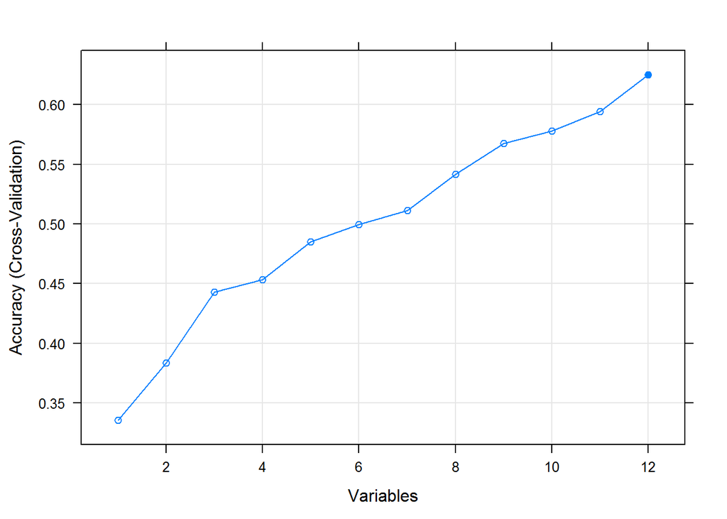

```r
#Accuracy vs number of variables plot
plot(results, type=c("g", "o"))
```

## Part 2: Model training

After data preparation and features selection, I will train two models. As we want to classify each activity/excercise to one of the groups (A-E) I decided to use the following approach: Model 1 will be Recursive Partitioning And Regression Trees and Model 2 will be Random Forest. I will pre-process the data (center and scale it).

```r
#Pre-processing and training with Recursive Partitioning And Regression Trees (model 1) and Random Forest (model 2)
model1<-train(classe~.,data=training, preProcess=c("center", "scale"), method="rpart")
model2<-train(classe~.,data=training, preProcess=c("center", "scale"), method="rf")
```

```r
#Model 1 Accuracy
model1$results['Accuracy']
```

```
##    Accuracy
## 1 0.5221194
## 2 0.3997814
## 3 0.3123854
```

```r
#Model 2 Accuracy
model2$results['Accuracy']
```

```
##    Accuracy
## 1 0.9820681
## 2 0.9817785
## 3 0.9756288
```

After printing both models, we can see that accuracy of optimal model is around 0.52 for Model 1 and 0.98 for Model 2.

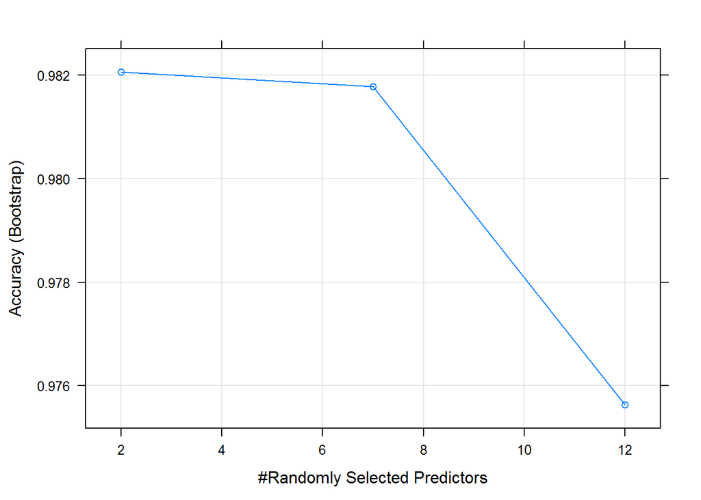

## Part 3: Model Validation

In last step I validate the models. I predict y (classe) values for testing dataset with Model 1 and Model 2.

```r
#Accuracy calcs and models comparison
#Model 1
prediction1<-predict(model1, testing)
#Model 2
prediction2<-predict(model2, testing)
```

And after printing Confusion Matrix Accuracy for both models, I decided to choose Model 2, based on Random Forest method, as it has pretty high accuracy on testing dataset (0.98) - higher than Model 1.

```r
#Confusion Matrix for Model 1&2
confMatrix1<-confusionMatrix(prediction1, testing$classe)
confMatrix2<-confusionMatrix(prediction2, testing$classe)
#Model 1 Accuracy
confMatrix1$overall['Accuracy']
```

```
## Accuracy
## 0.471028
```

```r
#Model 2 Accuracy
confMatrix2$overall['Accuracy']
```

```
##  Accuracy
## 0.9862362
```

```r
#Model 2 Sensitivity and Specificity
confMatrix2$byClass[,1:2]
```

```
##          Sensitivity Specificity
## Class: A   0.9946237   0.9971503
## Class: B   0.9762950   0.9964180
## Class: C   0.9775828   0.9934143
## Class: D   0.9854772   0.9969518
## Class: E   0.9926063   0.9989590
```